# Plant Machine Utilization analysis

Sridhar Kothalanka

2/21/2020

# Overview

In the below exercise EDA is performed on a predictive maintenance data set to understand the utilization of plant machines. The goal is to look at the charts and find out any hidden patterns in the dataset and help ask more questions to the domain expert.

## Steps

1. Load the necessary R libraries
2. Load the average utilization summary data
3. Plot the average utilization summary data
4. Quick observations
5. A closer look at each of the 2 machines(stations)
6. Station-1 how does the utilization look over a period of 1 year
7. Quick observations on Station-1
8. Station-2 how does the utilization look over a period of 1 year
9. Quick observations on Station-2
10. Station-1 and Station-2 side-by-side comparison
11. Summary

### 1. Load the necessary R libraries

```r
library(ggplot2)
library(magrittr)
library(dplyr)
library(tidyr)
```

### 2. Load the average utilization summary data

The raw data sets consists of observations of two machines across 3 shifts and its utilization over a period of 1 year. The raw data was processed and features like “day of the week” was added to get a quick understanding of any plant behavior patterns.

```r
df1 <- read.csv("../data/eda-pm-ds1/station1n2-avgUtilization.csv")
names(df1)[2] <- "avgUtilization"
```

### 3. Plot the average utilization summary data

Plotting the average utilization of all machines for each day of the week help us to understand if there are any weekly cycles

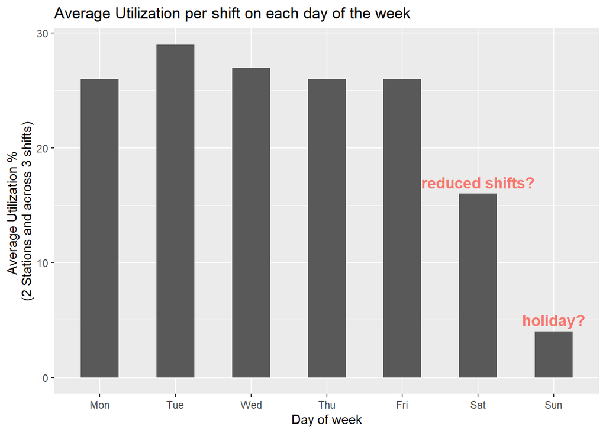

```r
annotation <- data.frame(x = c(6, 7), y = c(17, 5), label = c("reduced shifts?",
    "holiday?"))
df1 %>% ggplot(aes(x = factor(df1$weekDayName, levels = c("Mon", "Tue", "Wed", "Thu",
    "Fri", "Sat", "Sun")), y = avgUtilization)) + geom_bar(stat = "identity", width = 0.5) +
    xlab("Day of week") + ylab("Average Utilization % \n(2 Stations and across 3 shifts)") +
    geom_text(data = annotation, aes(x = x, y = y, label = label, color = "red",
        size = 7, angle = 0, fontface = "bold")) + theme(legend.position = "none") +
    ggtitle("Average Utilization per shift on each day of the week")
```

### 4. Quick observations

What we can infer from the above plot is:

1. On a Sunday there is little or no activity across the shifts, possibly it may be holiday
2. On a Saturday there is some reduction in shifts as a result the average is lower then the rest of the week days

### 5. A closer look at each of the 2 machines

Let us take a closer look at each of the two machines independently

- Station-1
- Station-2

and see how things show up

### 6. Station-1 how does the utilization look over a period of 1 year?

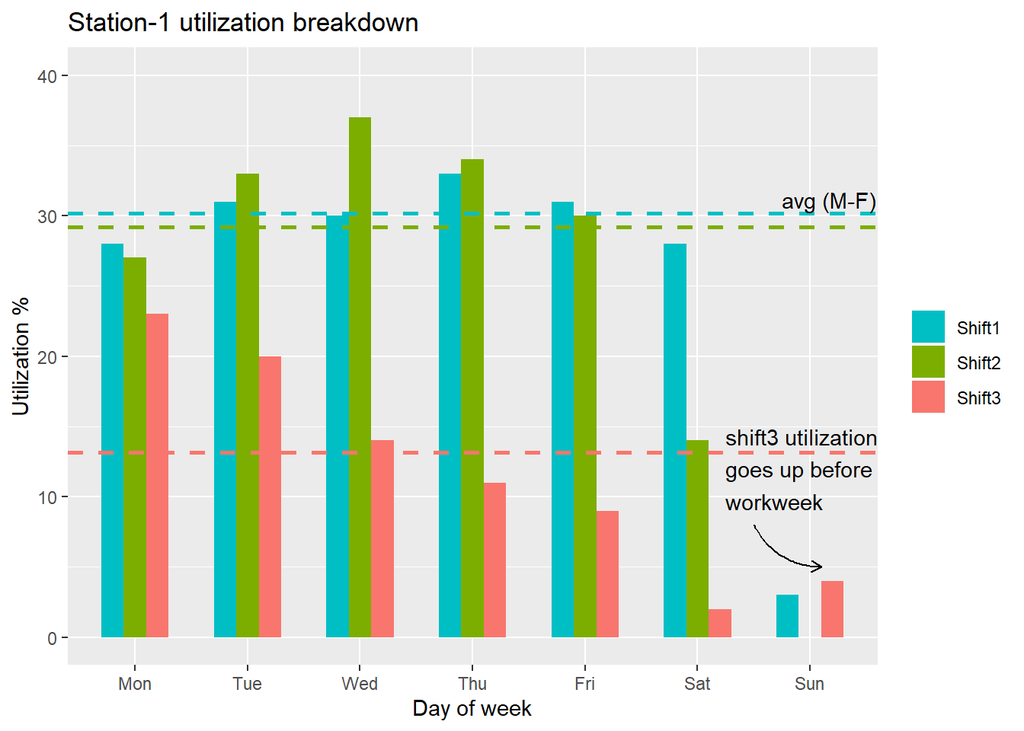

```r
df2 <- read.csv("../data/eda-pm-ds1/station1.csv") %>% gather(key = "Shift", value = "utilization",
    "Shift1", "Shift2", "Shift3")
df2$Shift <- factor(df2$Shift, levels = c("Shift1", "Shift2", "Shift3"))

dfx <- df2 %>% filter(df2$Shift == "Shift1" & df2$weekDayName != "Sun") %>% select(utilization)
shift1AvgExSun2 <- mean(dfx$utilization, na.rm = TRUE)
dfx <- df2 %>% filter(df2$Shift == "Shift2" & df2$weekDayName != "Sun") %>% select(utilization)
shift2AvgExSun2 <- mean(dfx$utilization, na.rm = TRUE)
dfx <- df2 %>% filter(df2$Shift == "Shift3" & df2$weekDayName != "Sun") %>% select(utilization)
shift3AvgExSun2 <- mean(dfx$utilization, na.rm = TRUE)

df2 %>% ggplot(aes(x = factor(df2$weekDayName, levels = c("Mon", "Tue", "Wed", "Thu",
    "Fri", "Sat", "Sun")), y = utilization, fill = Shift)) + geom_bar(position = "dodge",
    stat = "identity", width = 0.6) + ggtitle("Station1") + ylab("Utilization %") +
    xlab("Day of week") + ylim(0, 40) + scale_fill_manual("legend", values = c(Shift1 = "#00BFC4",
    Shift2 = "#7CAE00", Shift3 = "#F8766D")) + ggtitle("Station-1 utilization breakdown") +
    theme(legend.title = element_blank()) + annotate(geom = "curve", x = 6.5, y = 8,
    xend = 7.1, yend = 5, curvature = 0.3, arrow = arrow(length = unit(2, "mm"))) +
    annotate(geom = "text", x = 6.25, y = 12, label = "shift3 utilization \ngoes up before \nworkweek",
        hjust = "left") + geom_hline(yintercept = shift1AvgExSun2, linetype = "dashed",
    color = "#00BFC4", size = 1) + geom_hline(yintercept = shift2AvgExSun2, linetype = "dashed",
    color = "#7CAE00", size = 1) + geom_hline(yintercept = shift3AvgExSun2, linetype = "dashed",
    color = "#F8766D", size = 1) + annotate(geom = "text", x = 6.75, y = shift1AvgExSun2 +
    1, label = "avg (M-F)", hjust = "left")
```

### 7. Quick observations on Station-1

1. Utilization is below 50% during each shift
2. Shift 3 seems to utilizing the machines lesser than Shift 1 and 2
3. As before Saturday is running reduced shifts and Sunday may be a holiday

### 8. Station-2 how does the utilization look over a period of 1 year?

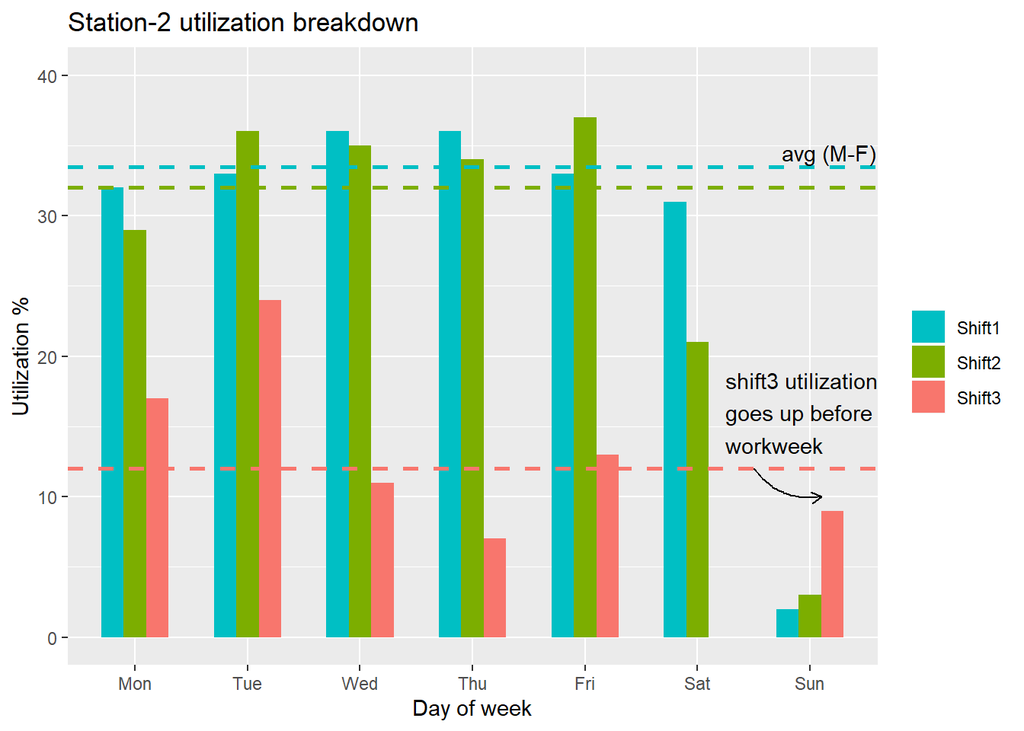

```r
df3 <- read.csv("../data/eda-pm-ds1/station2.csv") %>% gather(key = "Shift", value = "utilization",
    "Shift1", "Shift2", "Shift3")
df3$Shift <- factor(df3$Shift, levels = c("Shift1", "Shift2", "Shift3"))

dfx <- df3 %>% filter(df3$Shift == "Shift1" & df3$weekDayName != "Sun") %>% select(utilization)
shift1AvgExSun3 <- mean(dfx$utilization, na.rm = TRUE)
dfx <- df3 %>% filter(df3$Shift == "Shift2" & df3$weekDayName != "Sun") %>% select(utilization)
shift2AvgExSun3 <- mean(dfx$utilization, na.rm = TRUE)
dfx <- df3 %>% filter(df3$Shift == "Shift3" & df3$weekDayName != "Sun") %>% select(utilization)
shift3AvgExSun3 <- mean(dfx$utilization, na.rm = TRUE)

df3 %>% ggplot(aes(x = factor(df3$weekDayName, levels = c("Mon", "Tue", "Wed", "Thu",
    "Fri", "Sat", "Sun")), y = utilization, fill = Shift)) + geom_bar(position = "dodge",
    stat = "identity", width = 0.6) + ggtitle("Station1") + ylab("Utilization %") +
    xlab("Day of week") + ylim(0, 40) + scale_fill_manual("legend", values = c(Shift1 = "#00BFC4",
    Shift2 = "#7CAE00", Shift3 = "#F8766D")) + ggtitle("Station-2 utilization breakdown") +
    theme(legend.title = element_blank()) + annotate(geom = "curve", x = 6.5, y = 12,
    xend = 7.1, yend = 10, curvature = 0.3, arrow = arrow(length = unit(2, "mm"))) +
    annotate(geom = "text", x = 6.25, y = 16, label = "shift3 utilization \ngoes up before \nworkweek",
        hjust = "left") + geom_hline(yintercept = shift1AvgExSun3, linetype = "dashed",
    color = "#00BFC4", size = 1) + geom_hline(yintercept = shift2AvgExSun3, linetype = "dashed",
    color = "#7CAE00", size = 1) + geom_hline(yintercept = shift3AvgExSun3, linetype = "dashed",
    color = "#F8766D", size = 1) + annotate(geom = "text", x = 6.75, y = shift1AvgExSun3 +
    1, label = "avg (M-F)", hjust = "left")
```

### 9. Quick observations on Station-2

1. Utilization is below 50% during each shift
2. Shift 3 seems to utilizing the machines lesser than Shift 1 and 2
3. As before Saturday is running reduced shifts and Sunday may be a holiday

### 10. Station-1 and Station-2 side-by-side comparison

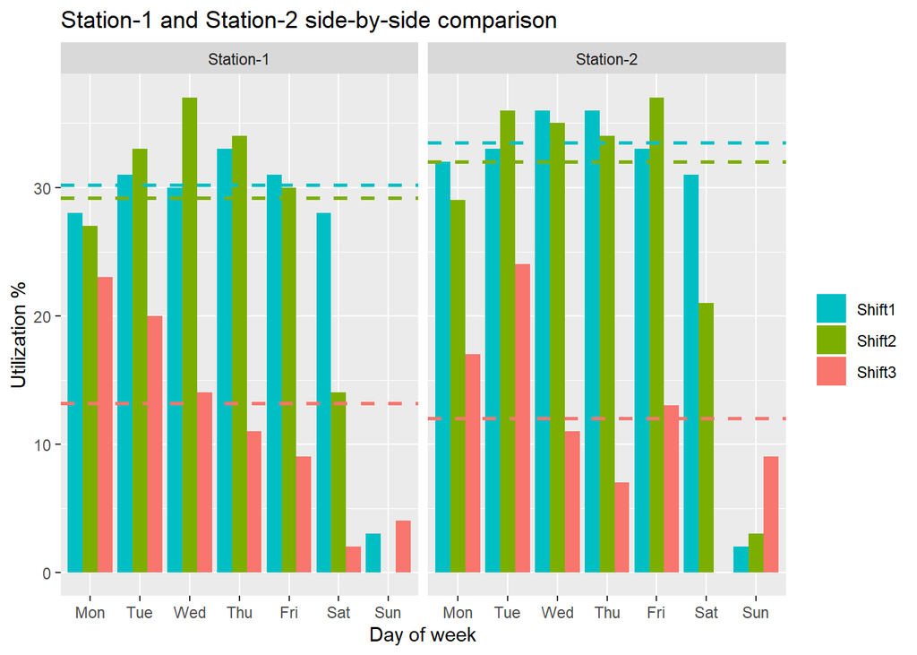

```r
df4 <- read.csv("../data/eda-pm-ds1/station1n2.csv")
df4$Station_ID[df4$Station_ID == 1] <- "Station-1"
df4$Station_ID[df4$Station_ID == 2] <- "Station-2"
df4$Shift[df4$Shift == 1] <- "Shift1"
df4$Shift[df4$Shift == 2] <- "Shift2"
df4$Shift[df4$Shift == 3] <- "Shift3"

avgShift1Lines <- data.frame(Station_ID = c("Station-1", "Station-2"), Z = c(shift1AvgExSun2,
    shift1AvgExSun3))
avgShift2Lines <- data.frame(Station_ID = c("Station-1", "Station-2"), Z = c(shift2AvgExSun2,
    shift2AvgExSun3))
avgShift3Lines <- data.frame(Station_ID = c("Station-1", "Station-2"), Z = c(shift3AvgExSun2,
    shift3AvgExSun3))

df4 %>% ggplot(aes(x = factor(df4$weekDayName, levels = c("Mon", "Tue", "Wed", "Thu",
    "Fri", "Sat", "Sun")), y = avgUtilization, fill = Shift)) + geom_bar(position = "dodge",
    stat = "identity") + ylab("Utilization %") + xlab("Day of week") + scale_fill_manual("legend",
    values = c(Shift1 = "#00BFC4", Shift2 = "#7CAE00", Shift3 = "#F8766D")) + ggtitle("Station-1 and Station-2 side-by-side comparison") +
    theme(legend.title = element_blank()) + facet_grid(~Station_ID) + geom_hline(data = avgShift1Lines,
    aes(yintercept = Z), linetype = "dashed", color = "#00BFC4", size = 1) + geom_hline(data = avgShift2Lines,
    aes(yintercept = Z), linetype = "dashed", color = "#7CAE00", size = 1) + geom_hline(data = avgShift3Lines,
    aes(yintercept = Z), linetype = "dashed", color = "#F8766D", size = 1)
```

### 11. Summary

1. The dataset is limited in terms of the available features (only provides how the machines are utilized)
2. If the data set can include the raw data used to compute utilization that may help broaden the analysis
3. Additional data (metrics) points associated with the machines itself will help to build predictive maintenance models